# Ocean pH

K. Dorheim

August 31, 2017

# House Keeping Notes

#### New Stuff

- CESM CO3 figs and CESM tos figs

#### To Do List

- Basin averages (Arcitic, Indian, Pacific, Atlantic, NH SH) - see pages 20 or notes from Aug 30 may be send a map to CH for approval before doing it
- Detrend the stuff by model/normalize talk to CL
- Do models all together and also facet by models
- WhAAT IS WRONG WITH THE GIT IGNORE???
- Diagnosis peak
- Future and past phase shift
- Break up into Marine Ecological Units ?

# Methodology

1. CDO - Concatenate cmip netcdfs and convert to absolute time
2. CDO - Get the field weighted mean via cdo
3. R - Plot monthly weighted mean in

# 1. pH

### Files Processed

#### Monthly pH netcdfs

Number of files with depth information.

```
## [1] "None."
```

Number summary of the CMIP5 files found on pic vs. the netcdfs processed by the cdo commands.

|  | number of files | model | domain | variable | experiment | ensemble |
| --- | --- | --- | --- | --- | --- | --- |
| CMIP5 files found | 40 | 14 | 1 | 1 | 2 | 1 |
| CMIP5 processed | NA | 14 | NA | 1 | 2 | 1 |

Summary of the CMIP5 files processed by the cdo commands.

| ensemble | historical | rcp85 |
| --- | --- | --- |
| r1i1p1 | 14 | 14 |

Unprocessed CMIP5 files

```
## [1] "No files identified were unprocessed"
```

### Exploratory Figures

Important Note: None of this figures include data from the *MRI-ESM1* model, pH is unrealistic.

### 1. a. Time Series Trends

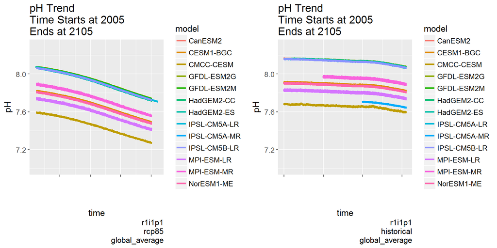

### 1. b. Mean Monthly pH by Model

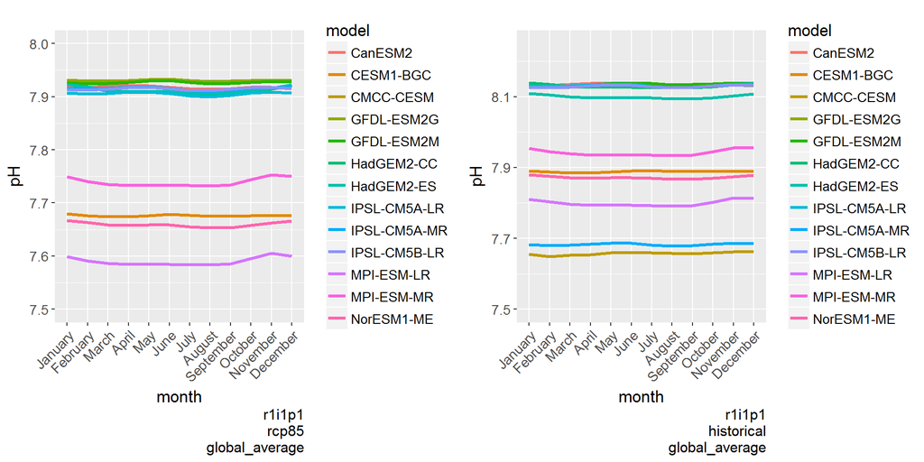

### 1. c. Mean Monthly

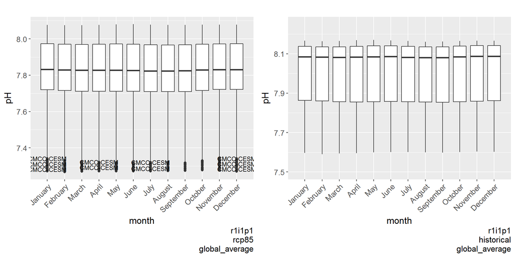

## CESM pH figs

### 1. d. CESM pH time series

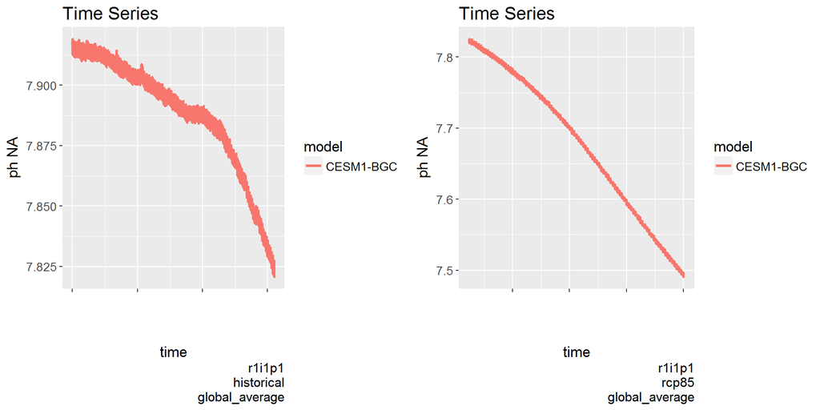

### 1. e. CESM pH monthly time series

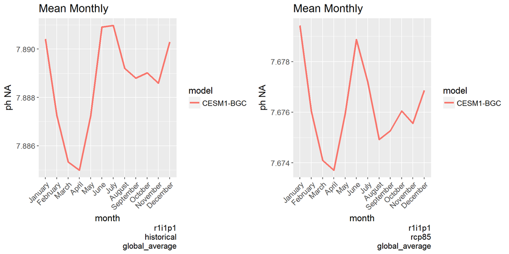

### 1. f. CESM pH boxplot

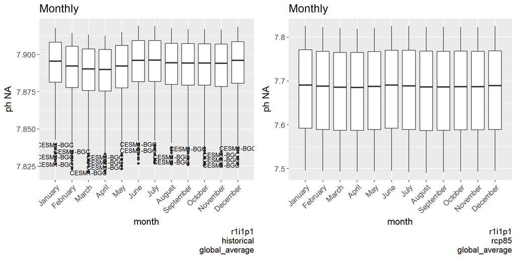

# 2. CO3

### Files Processed

#### Monthly CO3 netcdfs

Number of files with depth information.

```
## [1] "None."
```

Number summary of the CMIP5 files found on pic vs. the netcdfs processed by the cdo commands.

|  | number of files | model | domain | variable | experiment | ensemble |
| --- | --- | --- | --- | --- | --- | --- |
| CMIP5 files found | 66 | 12 | 1 | 1 | 2 | 1 |
| CMIP5 processed | NA | 12 | NA | 1 | 2 | 1 |

Summary of the CMIP5 files processed by the cdo commands.

| ensemble | historical | rcp85 |
| --- | --- | --- |
| r1i1p1 | 7 | 12 |

Unprocessed CMIP5 files

```
## [1] "No files identified were unprocessed"
```

### 2. a. Time Series Trends

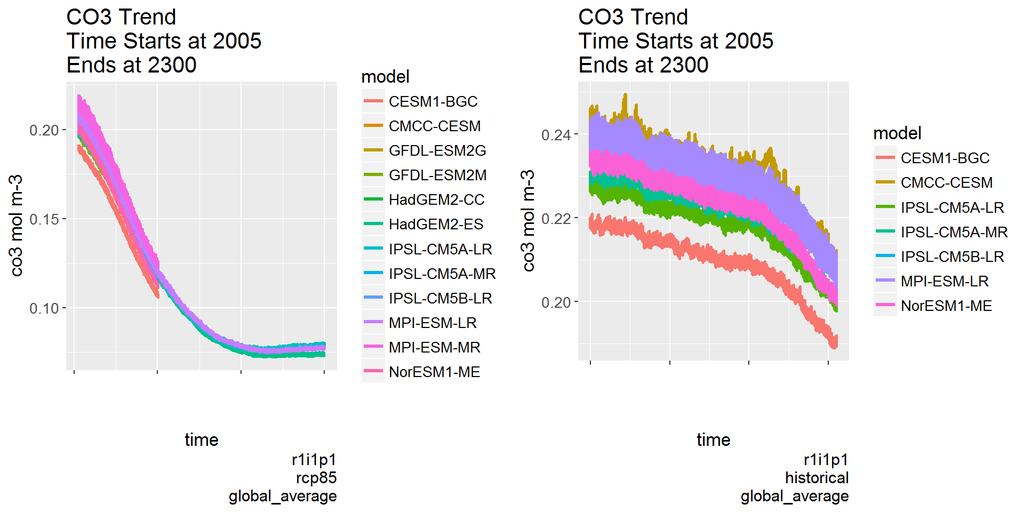

### 2. b. Mean Monthly CO3 by Model

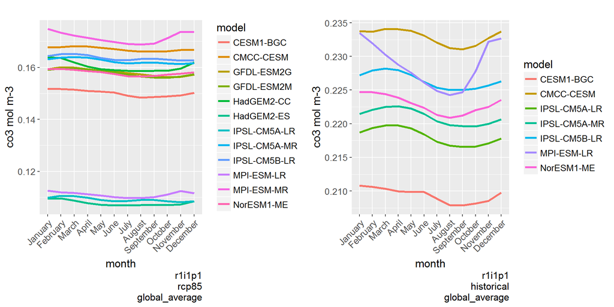

### 2. c. Mean Monthly

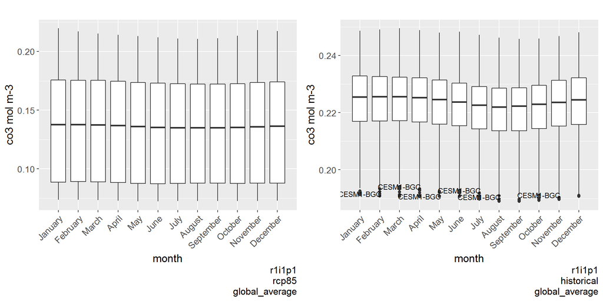

## CESM CO3 figs

### 2. d. CESM CO3 time series

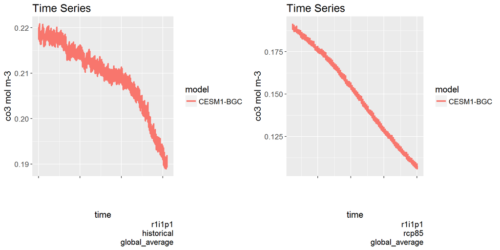

### 2. e. CESM CO3 monthly time series

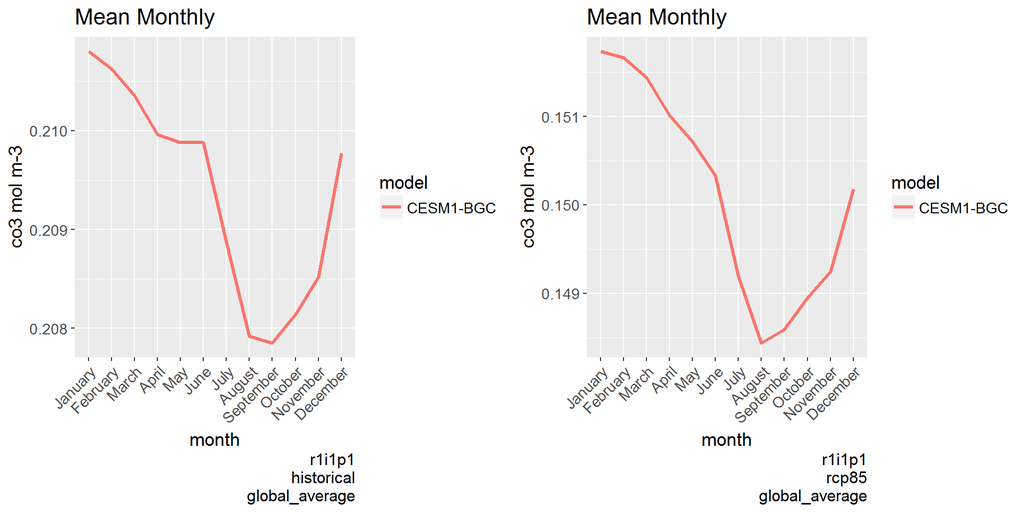

### 2. f. CESM CO3 boxplot

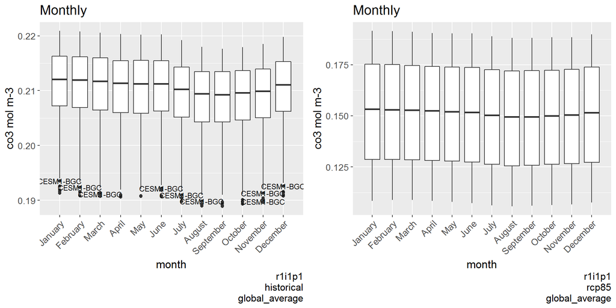

# 3. tos

### Files Processed

#### Monthly tos netcdfs

Number of files with depth information.

```
## [1] "None."
```

Number summary of the CMIP5 files found on pic vs. the netcdfs processed by the cdo commands.

|  | number of files | model | domain | variable | experiment | ensemble |
| --- | --- | --- | --- | --- | --- | --- |
| CMIP5 files found | 260 | 25 | 1 | 1 | 2 | 1 |
| CMIP5 processed | NA | 25 | NA | 1 | 2 | 1 |

Summary of the CMIP5 files processed by the cdo commands.

| ensemble | historical | rcp85 |
| --- | --- | --- |
| r1i1p1 | 17 | 24 |

Unprocessed CMIP5 files

```
## [1] "No files identified were unprocessed"
```

### 3. a. Time Series Trends

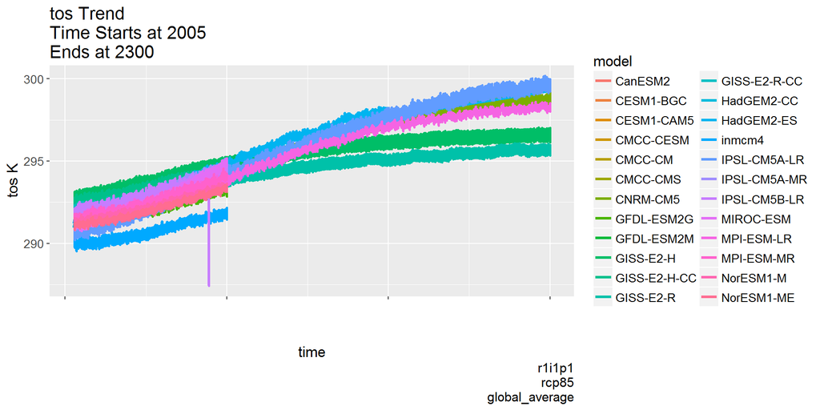

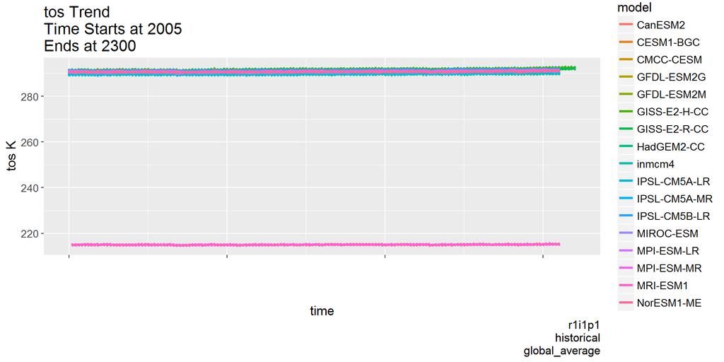

### 3. b. Mean Monthly tos by Model

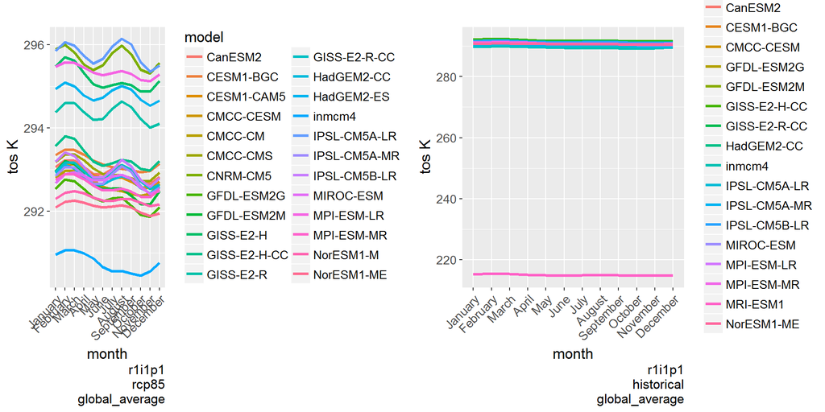

### 3. c. Mean Monthly

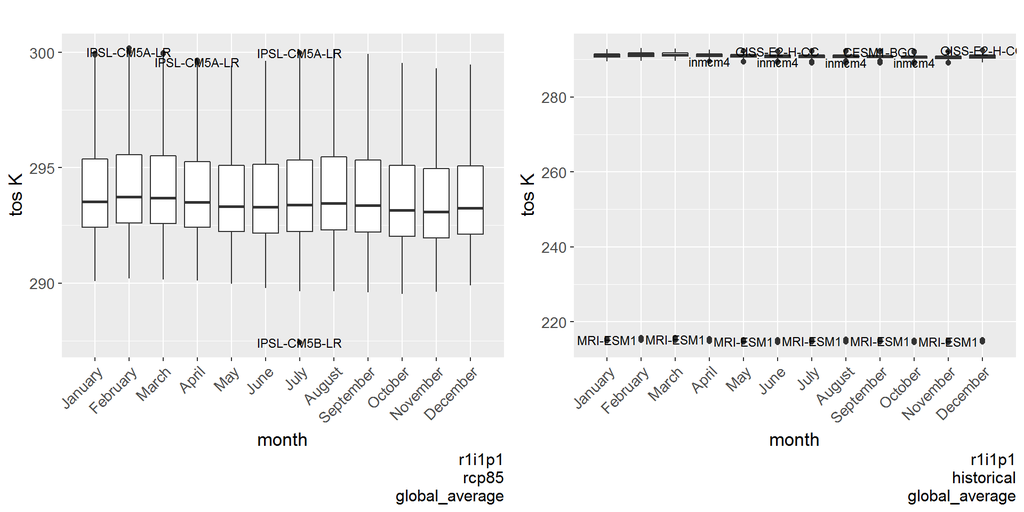

## CESM tos figs

### 3. d. CESM tos time series

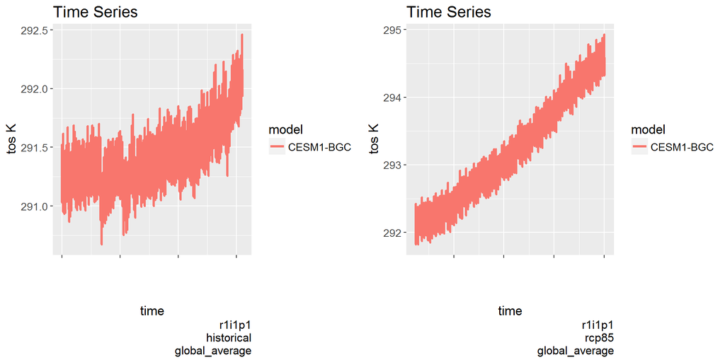

### 3. e. CESM tos monthly time series

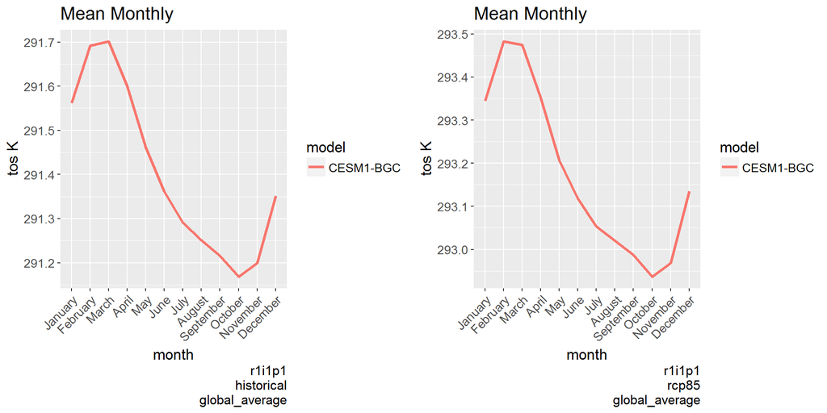

### 3. f. CESM tos boxplot

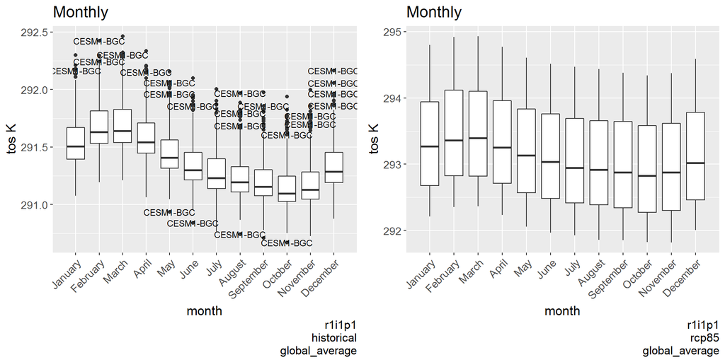

The End